# Dung beetles increase plant growth: a meta-analysis

Our two aims with this project are to conduct a systematic review and then meta-analysis to assess:

1. When dung beetles access dung, does plant growth increase in the immediate area?
2. Are there ecological and experimental factors (moderators) that influence this plant growth?

Our statistical analysis was largely influenced by supplementary material of Bishop and Nakagawa (2021).

Firstly we conducted a systematic review following the PRISMA 2020 method (Page et al., 2021).

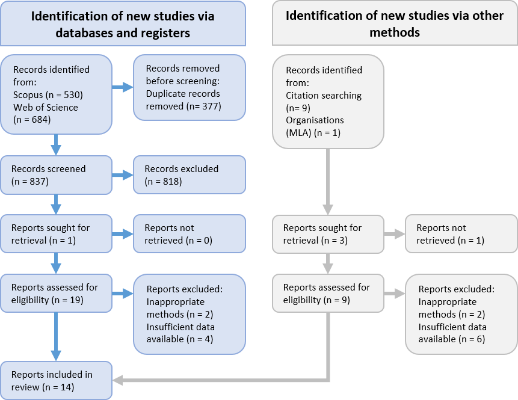

We then extracted data from those reports to conduct a meta-analysis.

Our data features correlated, or dependent, outcomes within studies (Noble et al., 2017). This correlation can be due to:  
**Shared control** - Where multiple treatments are compared to the same control (e.g. Manning et al., 2017).  
**Shared measurements** - Where more than one outcome/measurement is reported for the same study (e.g. Johnson et al., 2016).  
**Within-study temporal correlation** - Where the effect is measured at multiple timepoints (e.g. Nervo et al., 2017).  
For more information on non-dependent effect sizes see Nakagawa & Santos (2012), Noble et al. (2017) and Bishop & Nakagawa (2021).

We deal with the **shared control** aspect of our dataset before calculating the effect sizes.  
To do this we modify the control sample size (CONTROL_N) to account for those studies with shared controls. Next we divide the sample size of each control (CONTROL_N) by the number of shared controls within its study (SHAREDCONTROL_COUNT). This creates a SHARED_CONTROL_N value which is then used (in escalc) to calculate the effect size for each outcome.

We then use measures of plant growth between ‘dung+beetles’ and ‘dung_only’ treatments to calculate effect sizes. Effect sizes are calculated using a log transformed ratio of means, or log response ratio (lnRR) (Hedges et al., 1999). This is a usefull measurement as we can determine a percentage increase in plant growth. The metafor package was used to calculate the effect sizes (Viechtbauer 2010). For measure = “ROM”, the log is taken of the ratio of means, which makes this outcome measure symmetric around 0 and yields a corresponding sampling distribution that is closer to normality (Viechtbauer 2010).

Now we look at the effect sizes for any outliers and remove them if need be.

As the data also contain non-independence in the form of **shared measurements** and **within-study temporal correlation** we create a value called MULTIPLE_ENDPOINT_CLUSTERID. Whenever multiple plant traits were measured from the same plant at the same time, or when a single plant trait was measured from the same plant at different times, those outcomes received the same MULTIPLE_ENDPOINT_CLUSTERID. Sometimes studies had both Shared measurements and Within-study temporal correlation (e.g. Miranda et al., 1998).

To deal with non-independence we use multi-level meta-analytic models with variance–covariance matrices. We generate variance-covariance matrices based on a clustered variable, which was MULTIPLE_ENDPOINT_CLUSTERID.

We produce variance-covariance matrices with an assumed to have a correlation of 0.5, but this can be changed to higher or lower values as a sensitivity test. A correlation value (rho) of 0 indicates no correlation and 1 a perfect correlation (Dougherty et al., 2022).

We expect that when multiple plant traits were measured from the same plant at the same time (e.g. shoot weight and total weight), that the correlation will be high. When looking through the relevant studies, the effect of dung beetles on plant growth appears to vary through time, therefore, we assume when a single plant trait was measured from the same plant at different times that the correlation will be lower. As a compromise we select an rho of 0.5, which is a common assumption in meta-analyses (Dougherty et al., 2022) and the default value in the make_VCV_matrix function.  
**Note: Although I’ve just outlined why we chose an rho of 0.5, I’m tempted to ditch the rho of 0.5 and use a higher correlation value? In Bishop & Nakagawa they used an rho of 0.5, but they looked at yield AND various aspects of faba bean pods, which would probably be less-correlated than just looking at different aspects of yield alone. When using a higher correlation value (0.9) the plant growth moderators then appear influential (not saying that in a p-hacking kind of way, but maybe an rho of 0.9 highlights that the plant measurements are genuinely highly correlated and that demonstrates it)**

Now we compare the model with variance-covariance (vcov) matrices to a model without matrices (i.e. comparing a model that assumes non-dependence between effect sizes within studies, to a model that doesn’t). We do this by finding the one with the lowest AIC value.

The model with vcov matrices fits best, so we now report the results in the paper using model fitted with restricted maximum likelihood.  
Note: The model with vcov matrices is still the best fit with assumed variances of 0.1 and 0.9.

We then quantify the total variance (heterogeneity) attributable to each of the three levels.  
Here $I^{2}$ represents the amount of variation not attributable to sampling error. It is split into two parts; within clusters and between-cluster variation.

```
##                 i2_ml(RE.reml)
## I2_Total              79.63137
## I2_STUDYID            55.25596
## I2_ACCESSION_ID       24.37541
```

$I^{2}_{Level 2}$ (STUDYID) accounts for ~69.39% of heterogeneity and $I^{2}_{Level 3}$ (ACCESSION_ID) accounts for ~30.61% of heterogeneity. Therefore, this indicates that the majority of variance is attributable to heterogeneity variance within clusters on the second level (STUDYID).

Now we calculate the **overall estimate of plant growth increase from beetle activity**. This is done by back-transforming the lnRR.

Overall, in the studies we assessed, beetles increased plant growth by 13.5% above the ‘dung_only’ controls.  
Note: With an assumed correlation (rho) of 0.1 RE.reml.estimate = 0.133.  
Note: With an assumed correlation (rho) of 0.9 RE.reml.estimate = 0.1395.

Now we calculate the **overall confidence intervals and prediction intervals**. A prediction interval is the range within which the effect size of a new study outcome would likely be, given this new outcome was selected at random from the same population of the studies already included in the meta-analysis (Spineli & Pandis, 2020).

# Visualise the results

We can now make an orchard plot to visualise our results.  
The orchard plot contains confidence intervals (thick horizontal lines) and prediction intervals (thin horizontal lines) around an overall effect size estimate. Each point represents the scaled individual effect size of a study outcome. The position of each point along the x-axis is determined by its effect size. Points along the y-axis are scattered to both reduce overplotting and help visualise point density. See Nakagawa et al. (2021) for more information on orchard plots.

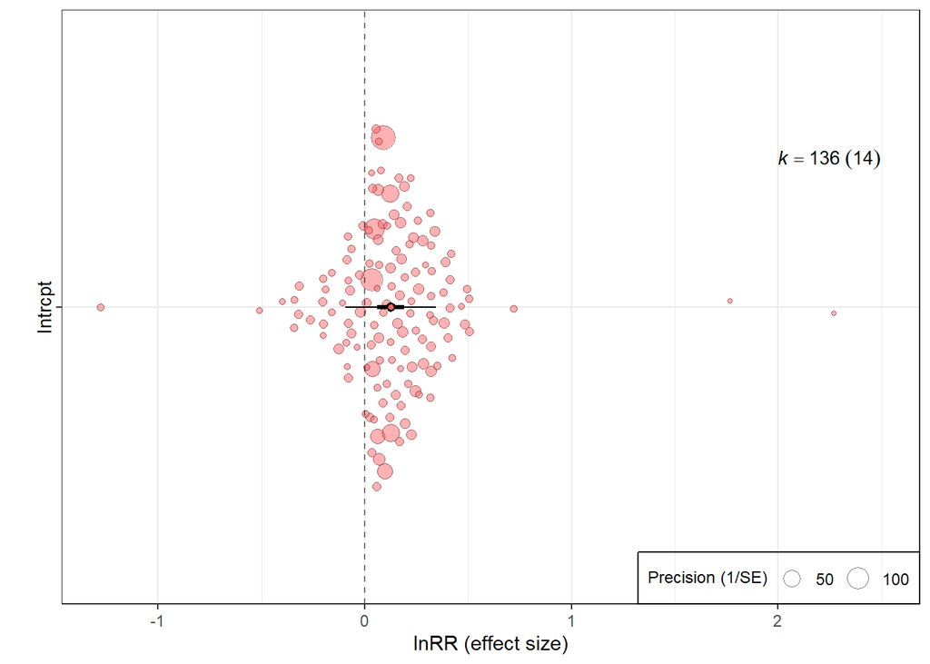

We can also make a caterpillar plot.  
The caterpillar plot shows effect sizes for each study outcome along with their confidence intervals. At the bottom of the plot there is a diamond that represents an overall mean effect size along with confidence intervals (mean in the center and CIs are the horizontal points of the diamond). This diamond lies within the prediction intervals.  
See Nakagawa et al. (2021) for more information on caterpillar plots.

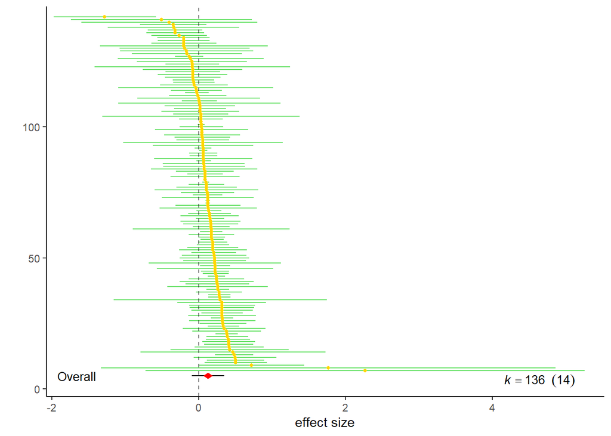

# Investigating moderators

Next we test to see if moderators improve the model fit.  
We couldn’t fully test interactions between moderators due to missing combinations of levels, so we tested them individually. We start by investigating the ecological moderators.

## Plant response

This moderator refers to the type of plant measurement used (either shoot height, root height, total height, shoot weight, root weight or total weight).

**Note: There is a warning message: Redundant predictors dropped from the model**

**Plant response is slightly influential to the overall estimate** (LRT RE.RESPONSE.ml vs RE, *p*=0.092).  
Response is slightly influential with assumed correlations (rho) of 0.1 (LRT RE.RESPONSE.ml vs RE, *p*=0.0725) and 0.9 (LRT RE.RESPONSE.ml vs RE, *p*=0.0629).

Shoot weight was the dominant plant response assessed in the studies. Other plant responses appear influential but have small sample sizes, so we group all the non-Shoot weight measurements together to create one group (with a larger collective sample size) and see if that is still influential.

**The grouped plant response is not influential to the overall estimate** (LRT RE.RESPONSE2.ml vs RE, *p*=0.776).

## Plant response area

This moderator refers to what section of the plant was measured (shoot, root or total), regardless of whether plant height or weight was measured.

**Plant response area is not influential to the overall estimate** (LRT RE.RESPONSE_AREA.ml vs RE, *p*=0.299).

## Plant response measurment type

This moderator refers to whether plant height or weight was measured, regardless of what section of the plant was measured.

**Plant response measurment type is not influential to the overall estimate** (LRT RE.RESPONSE_MEASUREMENT.ml vs RE, *p*=0.578).

## Beetle functional group

Some studies have unknown functional groups so we filter out those study outcomes with NAs listed for FUNCTIONAL_GROUP.

```
##
## Multivariate Meta-Analysis Model (k = 109; method: REML)
##
##   logLik  Deviance       AIC       BIC      AICc
##  14.7701  -29.5403  -17.5403   -1.6165  -16.6831
##
## Variance Components:
##
##             estim    sqrt  nlvls  fixed        factor
## sigma^2.1  0.0029  0.0541     10     no       STUDYID
## sigma^2.2  0.0074  0.0859    109     no  ACCESSION_ID
##
## Test for Residual Heterogeneity:
## QE(df = 105) = 136.9729, p-val = 0.0197
##
## Test of Moderators (coefficients 1:4):
## QM(df = 4) = 34.0676, p-val < .0001
##
## Model Results:
##
##                           estimate      se    zval    pval    ci.lb   ci.ub
## FUNCTIONAL_GROUPdweller     0.0786  0.0515  1.5252  0.1272  -0.0224  0.1795
## FUNCTIONAL_GROUPmultiple    0.2026  0.0497  4.0735  <.0001   0.1051  0.3001
## FUNCTIONAL_GROUProller      0.3371  0.1088  3.0993  0.0019   0.1239  0.5504
## FUNCTIONAL_GROUPtunneler    0.1477  0.0376  3.9264  <.0001   0.0740  0.2214
##
## FUNCTIONAL_GROUPdweller
## FUNCTIONAL_GROUPmultiple  ***
## FUNCTIONAL_GROUProller     **
## FUNCTIONAL_GROUPtunneler  ***
##
## ---
## Signif. codes:  0 '***' 0.001 '**' 0.01 '*' 0.05 '.' 0.1 ' ' 1
```

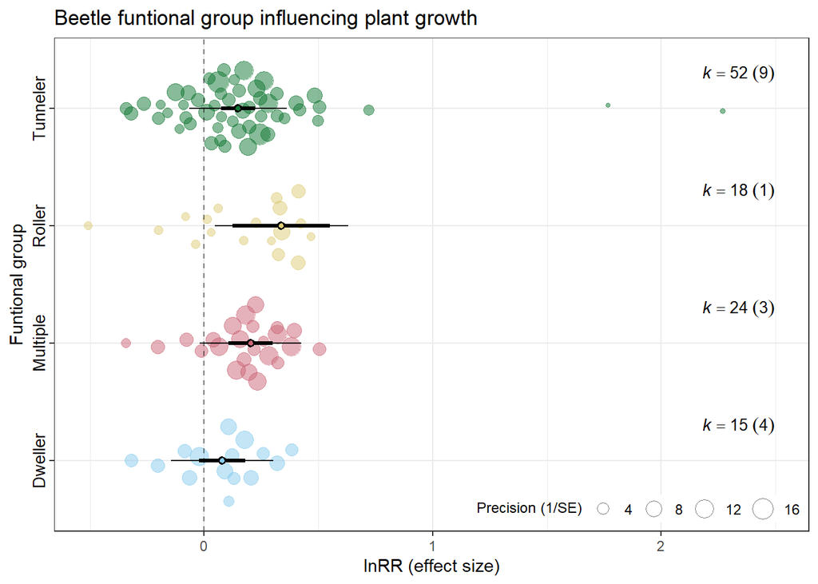

**Beetle functional group is influential to the overall estimate** (LRT RE.FG.ml vs RE.FG, *p*=0.039).

When looking at the Roller functional group, all 18 outcomes come from a single study, Barragán et al. (2022). After removing the Barragán et al. (2022) study, beetle functional group is still influential to the overall estimate, although less influential.

## Species richness

Some studies have unknown species richness so we filter out those study outcomes with NAs listed for SPECIES_RICHNESS.

**Note: There is a warning message: Redundant predictors dropped from the model**

**Species richness is not influential to the overall estimate** (LRT RE.SR.ml vs RE.SR, *p*= 0.449).

## Number of beetles

Some studies have an unknown number of beetles so we filter out those study outcomes with NAs listed for NUMBER_OF_BEETLES.

**The number of beetles (abundance) is not influential to the overall estimate** (LRT RE.NOB.ml vs RE.NOB, *p*= 0.904).

## Total beetle weight

Some studies have an unknown total beetle weight so we filter out those study outcomes with NAs listed for TOTAL_BEETLE_WEIGHT_IN_MG.  
We initially assessed this moderator and there was nearly a significant influence of (LRT: 3.1688, *p*=0.0751), but after removing two outliers from Badenhorst et al., 2018 there was no significant influence (LRT: 1.0456, *p*=0.3065). Therefore, we conclude that total beetle weight is not influential to the overall estimate.  
The two outliers from Badenhorst et al. (2018) can be included in the code chunk below by placing a # before the filter function.

## Dung quantity

Some studies have an unknown dung quantity so we filter out those study outcomes with NAs listed for DUNG_QUANTITY_IN_GRAMS

```
##
## Multivariate Meta-Analysis Model (k = 115; method: REML)
##
##   logLik  Deviance       AIC       BIC      AICc
##  27.7448  -55.4895  -47.4895  -36.5800  -47.1192
##
## Variance Components:
##
##             estim    sqrt  nlvls  fixed        factor
## sigma^2.1  0.0020  0.0453     14     no       STUDYID
## sigma^2.2  0.0021  0.0455    115     no  ACCESSION_ID
##
## Test for Residual Heterogeneity:
## QE(df = 113) = 248.7181, p-val < .0001
##
## Test of Moderators (coefficient 2):
## QM(df = 1) = 8.9208, p-val = 0.0028
##
## Model Results:
##
##                         estimate      se    zval    pval    ci.lb   ci.ub
## intrcpt                   0.0461  0.0370  1.2478  0.2121  -0.0263  0.1186
## DUNG_QUANTITY_IN_GRAMS    0.0001  0.0000  2.9868  0.0028   0.0000  0.0002  **
##
## ---
## Signif. codes:  0 '***' 0.001 '**' 0.01 '*' 0.05 '.' 0.1 ' ' 1
```

```
##
##     pred     se   ci.lb  ci.ub   pi.lb  pi.ub
## 1 0.0526 0.0330 -0.0120 0.1172 -0.0776 0.1828
## 2 0.6749 0.1765  0.3290 1.0208  0.3110 1.0388
```

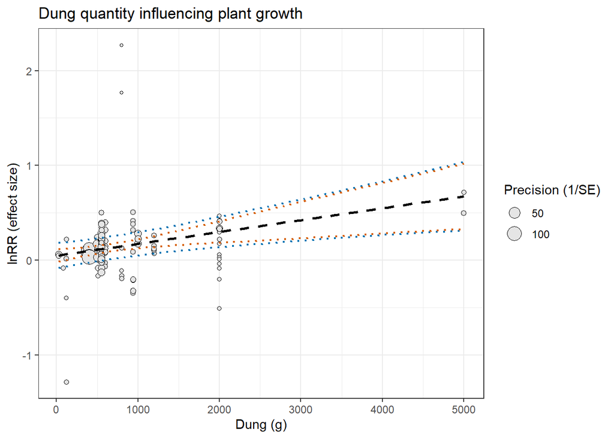

**Dung quantity is influential to the overall estimate**, this is when outliers from Badenhorst et al. (2018) are included (LRT RE.DQ.ml vs RE.DQ, *p*=0.003), and removed (LRT RE.DQ.ml vs RE.DQ, *p*=0.0028).  
With an assumed variance (rho) of 0.9 (LRT RE.DQ.ml vs RE.DQ, *p*=0.0025).

## Dung quantity (per surface area)

Some studies have an unknown dung quantity (per surface area) so we filter out those study outcomes with NAs listed for GRAMS_DUNG_PER_CM_SQUARED

```
##
## Multivariate Meta-Analysis Model (k = 105; method: REML)
##
##   logLik  Deviance       AIC       BIC      AICc
##  32.4502  -64.9004  -56.9004  -46.3615  -56.4923
##
## Variance Components:
##
##             estim    sqrt  nlvls  fixed        factor
## sigma^2.1  0.0019  0.0434     13     no       STUDYID
## sigma^2.2  0.0019  0.0440    105     no  ACCESSION_ID
##
## Test for Residual Heterogeneity:
## QE(df = 103) = 241.7234, p-val < .0001
##
## Test of Moderators (coefficient 2):
## QM(df = 1) = 4.8542, p-val = 0.0276
##
## Model Results:
##
##                            estimate      se    zval    pval   ci.lb   ci.ub
## intrcpt                      0.1271  0.0241  5.2651  <.0001  0.0798  0.1743
## GRAMS_DUNG_PER_CM_SQUARED    0.0087  0.0039  2.2032  0.0276  0.0010  0.0164
##
## intrcpt                    ***
## GRAMS_DUNG_PER_CM_SQUARED    *
##
## ---
## Signif. codes:  0 '***' 0.001 '**' 0.01 '*' 0.05 '.' 0.1 ' ' 1
```

```
##
##     pred     se  ci.lb  ci.ub  pi.lb  pi.ub
## 1 0.1271 0.0219 0.0842 0.1700 0.0080 0.2463
## 2 0.3489 0.0923 0.1679 0.5298 0.1365 0.5612
```

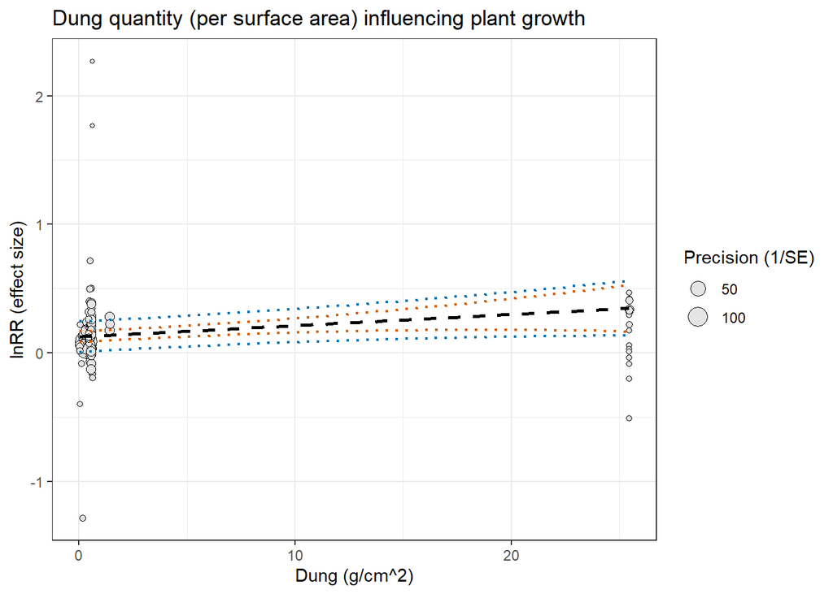

**Dung quantity (per surface area) is influential to the overall estimate**, this is when outliers from Badenhorst et al. (2018) are included (LRT RE.DQSA.ml vs RE.DQSA, *p*=0.026), and removed (LRT RE.DQSA.ml vs RE.DQSA, *p*=0.0258).  
With an assumed variance (rho) of 0.9 (LRT RE.DQSA.ml vs RE.DQSA, *p*=0.0046).

## Dung quantity (per beetle number)

Some studies have an unknown dung quantity (per beetle number) so we filter out those study outcomes with NAs listed for GRAMS_DUNG_PER_BEETLE_NUMBER.

**Dung quantity (per beetle number) is not influential to the overall estimate** (LRT RE.DQPBN.ml vs RE.DQPBN, *p*=0.974).  
With an assumed variance (rho) of 0.9 (LRT RE.DQPBN.ml vs RE.DQPBN, *p*=0.897).

## Dung quantity (per total beetle weight)

Some studies have an unknown dung quantity (per total beetle weight) so we filter out those study outcomes with NAs listed for GRAMS_DUNG_PER_BEETLE_WEIGHT.

**Dung quantity (per total beetle weight) is not influential to the overall estimate** (LRT RE.DQPBW.ml vs RE.DQPBW, *p*=0.711).  
With an assumed variance (rho) of 0.9 (LRT RE.DQPBW.ml vs RE.DQPBW, *p*=0.85).

## Plant clade

Is the clade of plant used in the experiment (monocot, dicot or both) influential?

**Plant clade is not influential to the overall estimate** (LRT RE.CLADE.ml vs RE, *p*=0.155).

## Plants germinated before dung addition

Was the timing of dung addition important (either before or after plants had germinated)?

**Plants germinated before dung addition is not influential to the overall estimate** (LRT RE.PLANTS_GERMINATED_BEFORE_DUNG_ADDITION.ml vs RE, *p*=0.278).  
Plants germinated before dung addition is slightly influential with assumed correlation (rho) of 0.9 (LRT RE.PLANTS_GERMINATED_BEFORE_DUNG_ADDITION.ml, RE, *p*=0.0791).

## Publication bias

Next we check for publication bias, which Nakagawa et al. (2017) recommend doing with more than one source .  
Firstly we produce a funnel plot, which includes the influential FUNCTIONAL_GROUP moderator.  
Nakagawa & Lagisz (2016) give brief instructions on interpreting a funnel plot.  
**NOTE: This may have to be re-done with all the influential moderators**

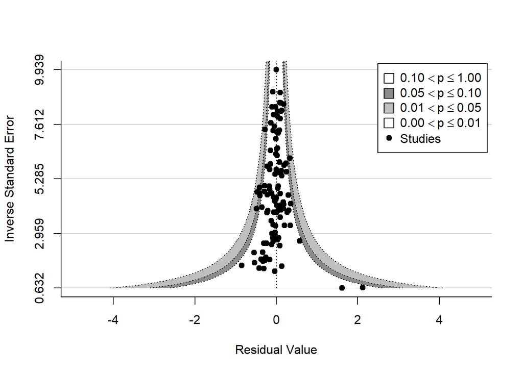

As a second assessment of publication bias, we use Egger’s regression (see Egger et al. (1997)), with the standard error, SE (sqrt(effect_size_variance)) as a moderator. A significant slope for SE indicates statistically significant funnel asymmetry after controlling for all other variables in the model (Bishop & Nakagawa, 2021).

```
##
## Multivariate Meta-Analysis Model (k = 136; method: REML)
##
##   logLik  Deviance       AIC       BIC      AICc
##  24.1036  -48.2072  -40.2072  -28.6158  -39.8971
##
## Variance Components:
##
##             estim    sqrt  nlvls  fixed        factor
## sigma^2.1  0.0097  0.0986     14     no       STUDYID
## sigma^2.2  0.0034  0.0586    136     no  ACCESSION_ID
##
## Test for Residual Heterogeneity:
## QE(df = 134) = 292.8276, p-val < .0001
##
## Test of Moderators (coefficient 2):
## QM(df = 1) = 0.6865, p-val = 0.4074
##
## Model Results:
##
##          estimate      se    zval    pval    ci.lb   ci.ub
## intrcpt    0.1008  0.0468  2.1534  0.0313   0.0091  0.1925  *
## mods       0.1534  0.1852  0.8285  0.4074  -0.2095  0.5164
##
## ---
## Signif. codes:  0 '***' 0.001 '**' 0.01 '*' 0.05 '.' 0.1 ' ' 1
```

The slope for SE (sqrt(effect_size_variance)) is non-significant *p*=0.407, indicating a lack of publication bias.

Now to visualise the Egger’s regression.  
Each point represents the scaled individual effect size of a study outcome. The dashed black line is the predicted loess line for the SE (sqrt(effect_size_variance)) variable/moderator. The orange lines represent the 95% confidence region and the blue lines represent the 95% prediction region.

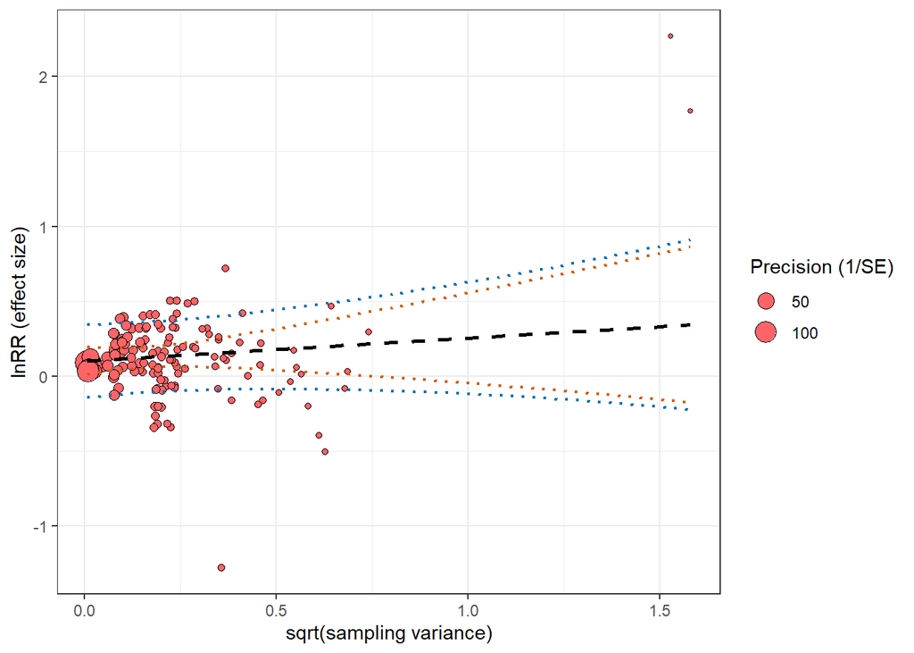

## References:

Bishop, J., & Nakagawa, S. (2021). Quantifying crop pollinator dependence and its heterogeneity using multi-level meta-analysis. Journal of Applied Ecology, 58(5), 1030–1042. https://doi.org/10.1111/1365-2664.13830  
Dougherty, L. R., Skirrow, M. J. A., Jennions, M. D., & Simmons, L. W. (2022). Male alternative reproductive tactics and sperm competition: a meta-analysis. Biological Reviews, 97, 1365–1388. https://doi.org/10.1111/brv.12846  
Hedges, L.V., Gurevitch, J. and Curtis, P.S. (1999), THE META-ANALYSIS OF RESPONSE RATIOS IN EXPERIMENTAL ECOLOGY. Ecology, 80: 1150-1156. https://doi.org/10.1890/0012-9658(1999)080[1150:TMAORR]2.0.CO;2 Johnson, S. N., Lopaticki, G., Barnett, K., Facey, S. L., Powell, J. R., & Hartley, S. E. (2016). An insect ecosystem engineer alleviates drought stress in plants without increasing plant susceptibility to an above-ground herbivore. Functional Ecology, 30(6), 894–902. https://doi.org/10.1111/1365-2435.12582  
Manning, P., Slade, E. M., Beynon, S. A., & Lewis, O. T. (2017). Effect of dung beetle species richness and chemical perturbation on multiple ecosystem functions. Ecological Entomology, 42(5), 577–586. https://doi.org/10.1111/een.12421  
Miranda, C. H. B., Santos, J. C. C., & Bianchin, I. (1998). Contribuição de Onthophagus gazella à melhoria da fertilidade do solo pelo enterrio de massa fecal bovina fresca. Brazilian Journal of Animal Science, 27, 681–685.  
Nakagawa, S., & Lagisz, M. (2016). Visualizing unbiased and biased unweighted meta-analyses. Journal of Evolutionary Biology, 29(10), 1914–1916. https://doi.org/10.1111/jeb.12945  
Nakagawa, Shinichi, & Santos, E. S. A. (2012). Methodological issues and advances in biological meta-analysis. Evolutionary Ecology, 26(5), 1253–1274. https://doi.org/10.1007/s10682-012-9555-5  
Nervo, B., Caprio, E., Celi, L., Lonati, M., Lombardi, G., Falsone, G., Iussig, G., Palestrini, C., Said-Pullicino, D., & Rolando, A. (2017). Ecological functions provided by dung beetles are interlinked across space and time: Evidence from 15N isotope tracing. Ecology, 98(2), 433–446. https://doi.org/10.1002/ecy.1653  
Noble, D. W. A., Lagisz, M., O’dea, R. E., & Nakagawa, S. (2017). Nonindependence and sensitivity analyses in ecological and evolutionary meta‐analyses. Molecular Ecology, 26, 2410–2425. https://doi.org/doi.org/10.1111/mec.14031  
Page, M. J., McKenzie, J. E., Bossuyt, P. M., Boutron, I., Hoffmann, T. C., Mulrow, C. D., Shamseer, L., Tetzlaff, J. M., Akl, E. A., Brennan, S. E., Chou, R., Glanville, J., Grimshaw, J. M., Hróbjartsson, A., Lalu, M. M., Li, T., Loder, E. W., Mayo-Wilson, E., McDonald, S., … Moher, D. (2021). The PRISMA 2020 statement: An updated guideline for reporting systematic reviews. The BMJ, 372. https://doi.org/10.1136/bmj.n71  
Spineli, L. M., & Pandis, N. (2020). Prediction interval in random-effects meta-analysis. American Journal of Orthodontics and Dentofacial Orthopedics, 157(4), 586–588. https://doi.org/10.1016/j.ajodo.2019.12.011  
Viechtbauer, W. (2010). Conducting meta-analyses in {R} with the {metafor} package. Journal of Statistical Software, 36(3), 1–48. https://doi.org/10.18637/jss.v036.i03